# HappyR : présentation du paquet R greed

Nicolas Jouvin

Loads the necessary packages.

```r
library(greed)
library(future) # allows parralel processing in greed()
library(aricode) # for ari computation
library(Matrix)
library(igraph)
library(mclust)

# data wrangling
library(dplyr)
library(tidyr)
library(purrr)
library(tidygraph)

# advanced ploting
library(ggpubr)
library(ggplot2)
library(ggraph)
library(ggwordcloud)
library(kableExtra)

set.seed(2134)

future::plan("multisession", workers=1) # increase workers for parallel processing
```

# Package overview

### Mathematical context

Now that we introduced the methodology we can proceed to a demonstration of the *greed* package on real datasets. As explained in the presentation, the methodology in quite versatile and applies to several data-types as long as we have a **model** for which an exact ICL may be derived
$$\text{ICL}_{ex} = \log p(X \mid Z, \beta) + \log p(Z \mid \alpha).$$

### Data-types currently handled by the greed package

Currently, the package handles the following tasks:

- **Continuous data clustering** with Gaussian Mixture Models. A [GMM](https://comeetie.github.io/greed/articles/GMM.html) tutorial is available. See also the documentation for the `Gmm` and `DiagGmm` S4 classes.
- **Graph data clustering** with the Stochastic Block Model or its degree corrected variants. A [SBM](https://comeetie.github.io/greed/articles/SBM.html) tutorial is available . See also the documentation for the `Sbm` and `dcSbm` S4 classes.
- **Categorical data clustering** with the Latent Class Analysis. An [LCA](https://comeetie.github.io/greed/articles/LCA.html) tutorial is available. See also the documentation for the `Lca` S4 class.
- **Count data clustering** with the Mixture of Multinomials model. A tutorial will soon be available. For now, we refer to the documentation for the `Mom` S4 class.
- **Mixed-typed** data clustering, *e.g.* categorical and numerical but the package handles virtually any type of data combination by stacking models on top of each data types. For example graph data with continuous or categorical data attached to the nodes are handled. A [CombinedModels](https://comeetie.github.io/greed/articles/CombinedModels.html) tutorial is available. See also the documentation for the `CombinedModels` S4 class.
- **Mixture of regression** for simultaneous clustering and fitting a regression model in each cluster. A [MoR](https://comeetie.github.io/greed/articles/MoR.html) tutorial is available. See also the documentation for the `MoR` S4 class.
- **Co-clustering** of binary and count-data via the Latent Block Model and its degree-corrected variant. A tutorial will soon be available. For now, we refer to the documentation for the `DcLbm` S4 class.

> For this practical session, we will focus on continuous, categorical and graph data clustering. Do not hesitate to try on your own, real dataset !

### Basic usage: the `greed` function

The package’s main entry point is the `greed` function with a typical call as follow

```r
sol = greed(
   X                  , # dataset to cluster (mandatory)
   K = 20             , # number of initial clusters (optional)
   model = Gmm()      , # model to use and its prior parameters (optional)
   alg = Hybrid()     , # algorithm to use and its parameters (optional)
   verbose= FALSE    )  # verbosity level (optional)
```

Let us decompose this call.

- First, `X` contains the dataset do cluster. Depending on the task it can be an continuous or discrete $n \times p$ matrix of multivariate observations, or an $n \times n$ adjacency matrix.
- Then, the `model` argument defines the observational model, *i.e* the expression of $\log p (X \mid Z, \beta)$ that shall be used. It is optional as the package can infer the model from `X` data-type (continous, factor, graph). The hyper-parameters $\beta$ can be specified.
- `alg` specifies which algorithm to use among hybrid GA, standard GA, greedy with clever initialization or multiple random initializations.

### S4 class abstraction

The **greed** package uses S4 class abstraction to specify the `model`, `alg` arguments as well as the results of the `greed()` function. This allows to use *generic* method to explore the results such as

- `plot(sol, ...)`
- `clustering(sol)`
- `cut(sol, )`
- `coef(sol)`

# Introductory example on simulated data: graph clustering with binary SBM

We will begin with a graph clustering example with a binary SBM model.

### The model

The stochastic block model (SBM) is a random graph model of the adjacency matrix $\mathbf{X}$ widely used for graph clustering. In this model, the probability of an edge $(i,j)$ is driven by the cluster membership of node $i$ and $j$, hence the **block** terminology. The Bayesian formulation of a binary SBM is as follow

$$\begin{align*}
\forall (k,l) \in [K]^2, \quad \theta_{kl} & \sim \textrm{Beta}(a_0,
b_0) \\
\forall (i,j) \in [n]^2, \quad x_{ij} \mid \{ z_{ik}z_{jl}=1 \}, \theta
& \sim \mathcal{B}(\theta_{kl})
\end{align*}$$

Beta-Bernoulli conjugacy allows to derive an exact expression of $\log p(X\mid Z, \beta) = \log \int_\theta p(X \mid Z, \theta) p(\theta \mid \beta) \, d\theta$. Here, the hyper-parameters $\beta = (a_0, b_0)$ may be set to default “non-informative” values $a_0=b_0=1$ (Beta(1,1) is uniform on $[0,1]$).

### Reproducing the slides example: nested SBM simulation

#### Simulate the data

```r
N=1600
K=15
prop=rep(1/K,K)
lambda  = 0.1
lambda_o = 0.025
Ks=5
theta = bdiag(lapply(1:(K/Ks), function(k){matrix(lambda_o,Ks,Ks)+diag(rep(lambda,Ks))}))+0.001
sbm = rsbm(N,prop,theta)
dim(sbm$x)
```

```
#> [1] 1600 1600
```

We have a graph with 1600 nodes. The true connectivity matrix $\theta$ can be visualized and any (reordered) adjacency matrices from this SBM model would have the same profile.

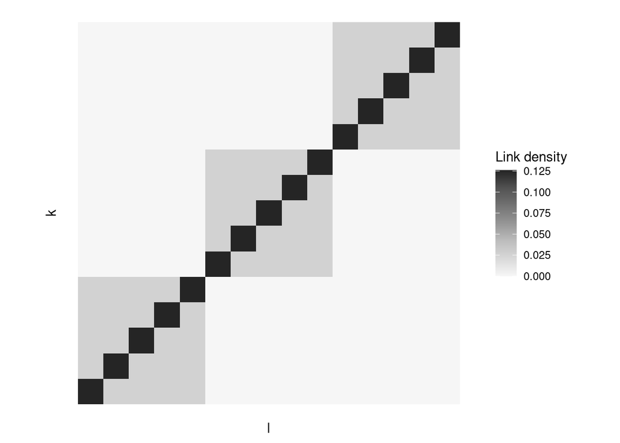

```r
theta.long=tibble(p=as.numeric(theta),k=rep(1:K,K),l=rep(1:K,each=K))

ggplot(theta.long)+
  geom_tile(aes(x=l,y=k,fill=p))+
  scale_x_discrete()+
  scale_y_discrete()+
  ggplot2::scale_fill_distiller("Link density", palette = "Greys", direction = 1, limits = c(0, max(theta)))+theme_minimal()+coord_equal()
```

#### Prepare the data and call `greed`

```r
sol_sbmsim <- greed(X = sbm$x, model = Sbm(), alg = Hybrid(pop_size = 40))
```

```
#>
#> ── Fitting a guess SBM model ──
#>
#> ℹ Initializing a population of 40 solutions.
#> ℹ Generation 1 : best solution with an ICL of -171800 and 15 clusters.
#> ℹ Generation 2 : best solution with an ICL of -168669 and 12 clusters.
#> ℹ Generation 3 : best solution with an ICL of -167104 and 15 clusters.
#> ℹ Generation 4 : best solution with an ICL of -167104 and 15 clusters.
#> ── Final clustering ──
#>
#> ── Clustering with a SBM model 15 clusters and an ICL of -167104
```

```r
K(sol_sbmsim)
```

```
#> [1] 15
```

We see that `greed` correctly recovers the $K=15$ clusters, in a reasonable amount of time. What about the recovered partition ? We can explore the results thanks to dedicated function in the package.

#### Exploring the results

```r
cl <- clustering(sol_sbmsim)
table(truth=sbm$cl, est=cl) %>% kable(row.names = T) %>% kable_styling(full_width = F)
```

|  | 1 | 2 | 3 | 4 | 5 | 6 | 7 | 8 | 9 | 10 | 11 | 12 | 13 | 14 | 15 |
| --- | --- | --- | --- | --- | --- | --- | --- | --- | --- | --- | --- | --- | --- | --- | --- |
| 1 | 0 | 0 | 0 | 0 | 0 | 0 | 0 | 0 | 0 | 0 | 0 | 94 | 0 | 0 | 0 |
| 2 | 0 | 0 | 0 | 0 | 0 | 0 | 0 | 0 | 0 | 0 | 0 | 0 | 0 | 111 | 0 |
| 3 | 0 | 0 | 0 | 0 | 0 | 0 | 0 | 0 | 0 | 0 | 0 | 0 | 0 | 0 | 129 |
| 4 | 0 | 0 | 0 | 0 | 0 | 0 | 0 | 0 | 0 | 0 | 87 | 0 | 0 | 0 | 0 |
| 5 | 0 | 0 | 0 | 0 | 0 | 0 | 0 | 0 | 0 | 0 | 0 | 0 | 103 | 0 | 0 |
| 6 | 0 | 0 | 0 | 109 | 0 | 0 | 0 | 0 | 0 | 0 | 0 | 0 | 0 | 0 | 0 |
| 7 | 0 | 108 | 0 | 0 | 0 | 0 | 0 | 0 | 0 | 0 | 0 | 0 | 0 | 0 | 0 |
| 8 | 0 | 0 | 0 | 0 | 100 | 0 | 0 | 0 | 0 | 0 | 0 | 0 | 0 | 0 | 0 |
| 9 | 122 | 0 | 0 | 0 | 0 | 0 | 0 | 0 | 0 | 0 | 0 | 0 | 0 | 0 | 0 |
| 10 | 0 | 0 | 105 | 0 | 0 | 0 | 0 | 0 | 0 | 0 | 0 | 0 | 0 | 0 | 0 |
| 11 | 0 | 0 | 0 | 0 | 0 | 89 | 0 | 0 | 1 | 0 | 0 | 0 | 0 | 0 | 0 |
| 12 | 0 | 0 | 0 | 0 | 0 | 0 | 0 | 109 | 0 | 0 | 0 | 0 | 0 | 0 | 0 |
| 13 | 0 | 0 | 0 | 0 | 0 | 0 | 0 | 0 | 0 | 114 | 0 | 0 | 0 | 0 | 0 |
| 14 | 0 | 0 | 0 | 0 | 0 | 0 | 0 | 0 | 117 | 0 | 0 | 0 | 0 | 0 | 0 |
| 15 | 0 | 0 | 0 | 0 | 0 | 0 | 102 | 0 | 0 | 0 | 0 | 0 | 0 | 0 | 0 |

```r
aricode::ARI(sbm$cl, cl)
```

```
#> [1] 0.9987085
```

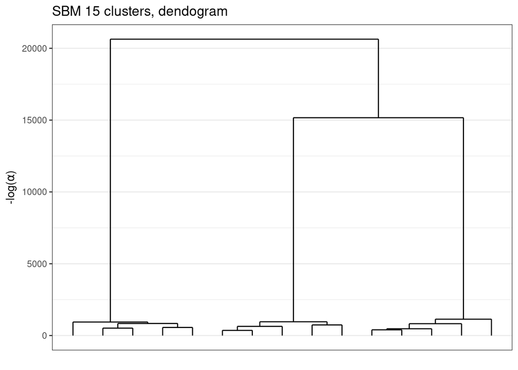

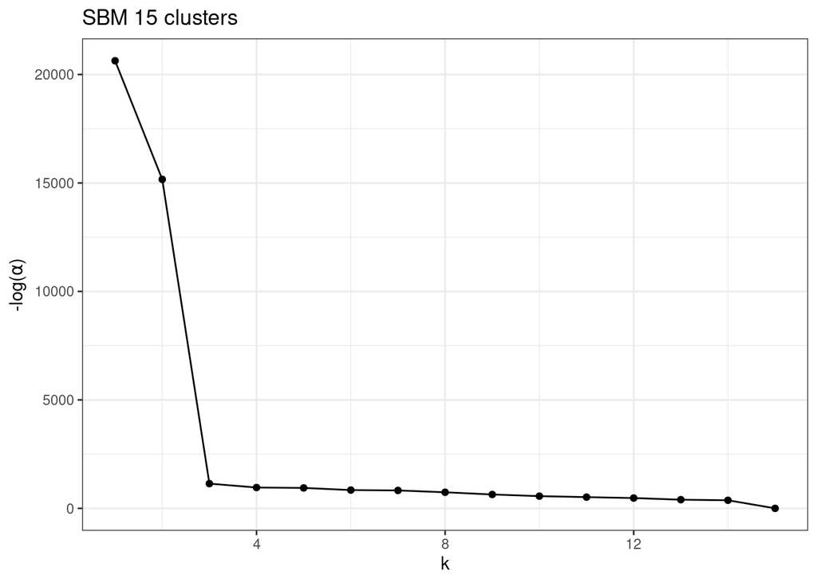

```r
plot(sol_sbmsim, type="tree")
plot(sol_sbmsim, type="path")
```

The fusion level corresponds to the amount of regularization $\log(\alpha)$ needed to unlock the fusion. It is consistent with the hierarchical structure of the dataset, and the leaf ordering algorithm provides a “natural” ordering of the cluster that can be used in other plotting functions.

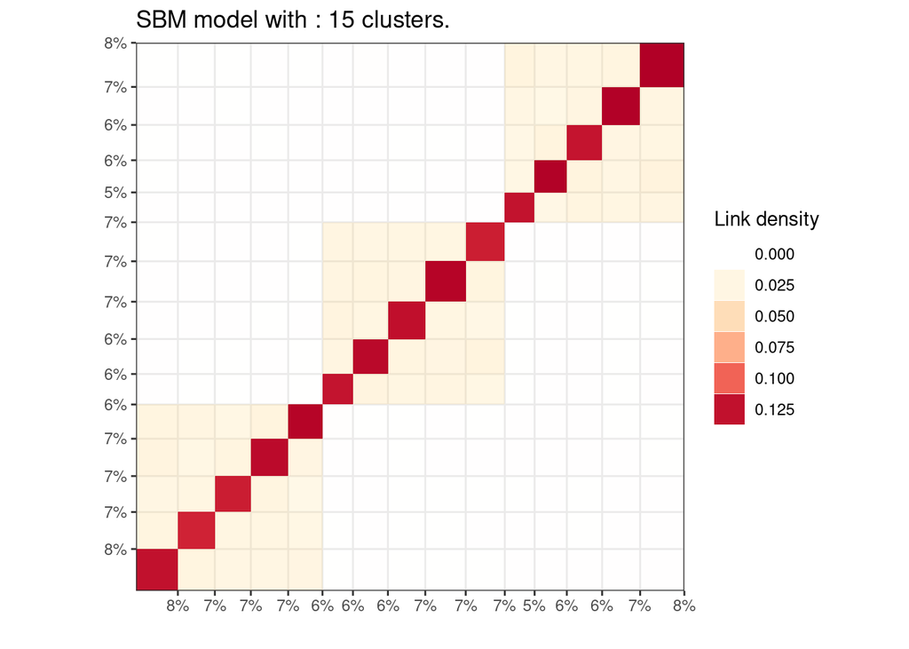

```r
plot(sol_sbmsim, type="blocks")
```

An alternative visualization of the aggregated graph is the `nodelink` diagram

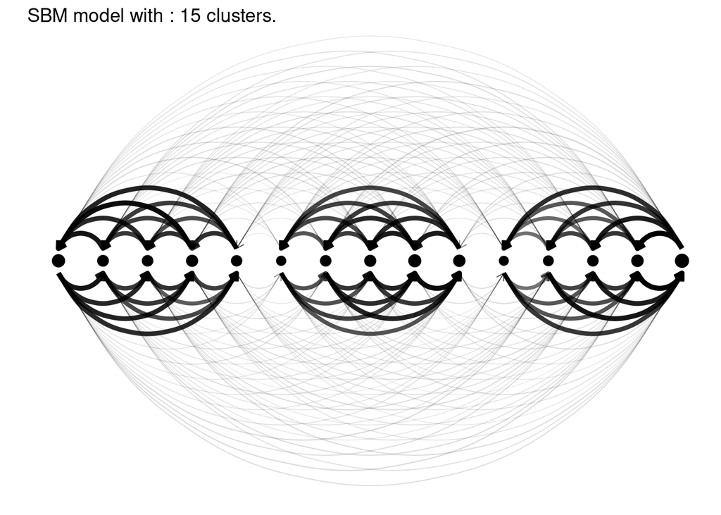

```r
plot(sol_sbmsim, type="nodelink")
```

#### Exploring coarser partitions with `cut()`

Eventually, one can explore coarser scales of the hierarchy and still use the same type of functions.

```r
sol_sbm_K3 = cut(sol_sbmsim, 3)
table(clustering(sol_sbm_K3), sbm$cl) %>% kable(row.names=T)
```

|  | 1 | 2 | 3 | 4 | 5 | 6 | 7 | 8 | 9 | 10 | 11 | 12 | 13 | 14 | 15 |
| --- | --- | --- | --- | --- | --- | --- | --- | --- | --- | --- | --- | --- | --- | --- | --- |
| 1 | 0 | 0 | 0 | 0 | 0 | 109 | 108 | 100 | 122 | 105 | 0 | 0 | 0 | 0 | 0 |
| 2 | 0 | 0 | 0 | 0 | 0 | 0 | 0 | 0 | 0 | 0 | 90 | 109 | 114 | 117 | 102 |
| 3 | 94 | 111 | 129 | 87 | 103 | 0 | 0 | 0 | 0 | 0 | 0 | 0 | 0 | 0 | 0 |

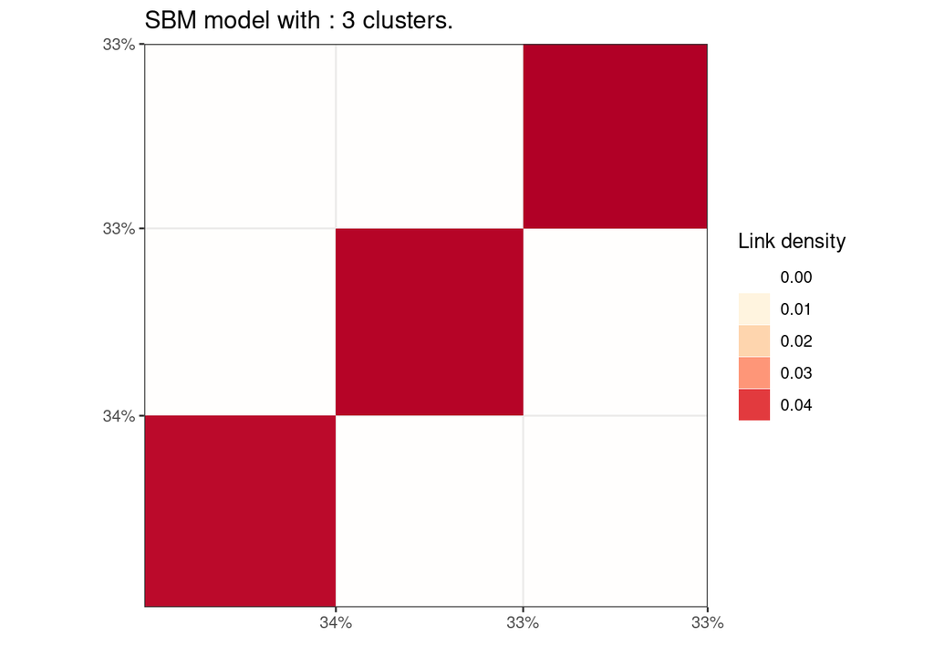

```r
plot(sol_sbm_K3, type="blocks")
```

#### Getting a conditional parameter estimate with `coef()`

At any stage $k \leq \hat{K}$ of the hierarchy, one can get a conditional MAP estimate of the observational model parameters $\hat{\theta} \mid \hat{Z}^{(k)}$ which maximizes $\log p(X \mid \hat{Z}^{(k)}, \theta)$.

```r
hat_theta= coef(sol_sbmsim)$theta
mean(abs(hat_theta-theta)) # l1 relative error, no permutation needed here.
```

```
#> [1] 0.0006745534
```

### A real data example: the Book dataset

The **Books** dataset was gathered by Valdis Krebs and is attached to the **greed** package. It consist of a co-purchasing network of $N=105$ books on US politics. Two books have an edge between them if they have been frequently co-purchased together. We have access to the labels of each book according to its political inclination: conservative (“n”), liberal (“l”) or neutral (“n”).

```r
data(Books)

sol_dcsbm <- greed(Books$X,model = DcSbm())
```

```
#>
#> ── Fitting a guess DCSBM model ──
#>
#> ℹ Initializing a population of 20 solutions.
#> ℹ Generation 1 : best solution with an ICL of -1349 and 4 clusters.
#> ℹ Generation 2 : best solution with an ICL of -1346 and 4 clusters.
#> ℹ Generation 3 : best solution with an ICL of -1346 and 4 clusters.
#> ── Final clustering ──
#>
#> ── Clustering with a DCSBM model 3 clusters and an ICL of -1345
```

```r
sol_sbm   <- greed(Books$X,model = Sbm())
```

```
#>
#> ── Fitting a guess SBM model ──
#>
#> ℹ Initializing a population of 20 solutions.
#> ℹ Generation 1 : best solution with an ICL of -1279 and 8 clusters.
#> ℹ Generation 2 : best solution with an ICL of -1259 and 6 clusters.
#> ℹ Generation 3 : best solution with an ICL of -1255 and 6 clusters.
#> ℹ Generation 4 : best solution with an ICL of -1255 and 6 clusters.
#> ── Final clustering ──
#>
#> ── Clustering with a SBM model 5 clusters and an ICL of -1254
```

The network as been automatically recognized as an undirected graph, as we can see see in the fitted models prior:

```r
prior(sol_dcsbm)@type
```

```
#> [1] "undirected"
```

```r
prior(sol_sbm)@type
```

```
#> [1] "undirected"
```

For this dataset, the regular SBM model seems to reach a better ICL solution than its degree-correction variant. Still, we can visualize both aggregated adjacency matrices and the dendrogram.

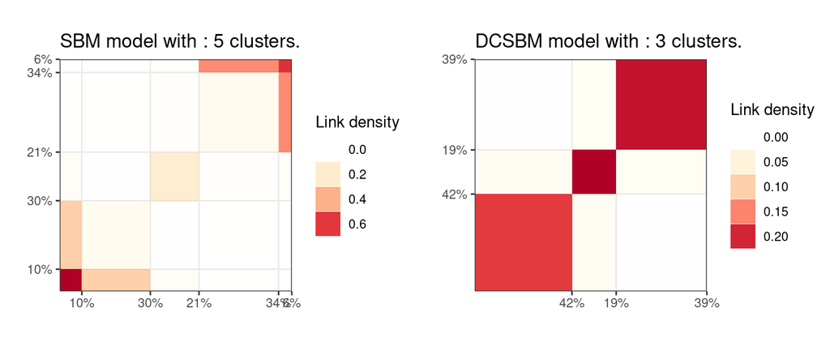

Block matrix representation of the DcSbm and Sbm solution found with greed on the Book network.

```r
bl_sbm = plot(sol_sbm,type='blocks')
bl_dcsbm = plot(sol_dcsbm,type='blocks')
ggarrange(bl_sbm,bl_dcsbm)
```

It is also possible to use external R packages to plot the graph layout with node color as clusters and node size as book popularity (computed using centrality degree). Here, we represent the result for the SBM solution with 5 clusters. One can see a hierarchical clustering structure appearing, with a central cluster of neutral books in-between two densely connected set. In each of these two dense set, there is a clear distinction between popular books (heavily purchased) and more peripheral ones, indicated by node size.

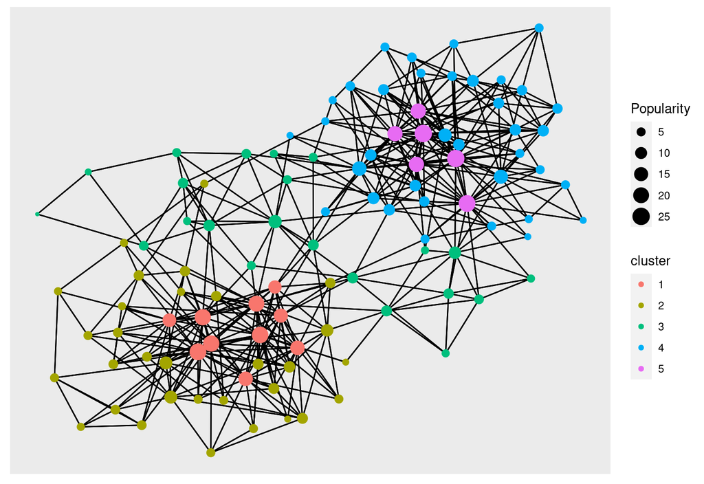

Ggraph plot of the book network with node colors given by the clustering found with greed and an Sbm model.

```r
graph <- igraph::graph_from_adjacency_matrix(Books$X) %>%
  as_tbl_graph() %>%
  mutate(Popularity = centrality_degree())  %>%
  activate(nodes) %>%
  mutate(cluster=factor(clustering(sol_sbm),1:K(sol_sbm)))

# plot using ggraph
ggraph(graph, layout = 'kk') +
    geom_edge_link() +
    geom_node_point(aes(size = Popularity,color=cluster))
```

Finally, we can look at both models solutions for $K=3$ and their confusion matrix. We see that both partition make sense according to the available political label.

SBM

|  | c | l | n |
| --- | --- | --- | --- |
| 1 | 1 | 38 | 2 |
| 2 | 8 | 5 | 9 |
| 3 | 40 | 0 | 2 |

DC-SBM

|  | c | l | n |
| --- | --- | --- | --- |
| 1 | 41 | 0 | 3 |
| 2 | 7 | 5 | 8 |
| 3 | 1 | 38 | 2 |

```r
table(clustering(cut(sol_sbm, 3)), clustering(sol_dcsbm))
```

```
#>
#>      1  2  3
#>   1  0  0 41
#>   2  2 20  0
#>   3 42  0  0
```

```r
aricode::ARI(clustering(cut(sol_sbm, 3)), clustering(sol_dcsbm))
```

```
#> [1] 0.9503619
```

# Continuous data clustering with GMM

### The model

Without any constraints, the Bayesian formulation of GMMs leading to a tractable exact ICL expression uses a Normal and inverse-Wishart conjugate prior on the mean and covariances $\mathbf{\theta} = (\mathbf{\mu}_k, \mathbf{\Sigma}_k)_k$. This prior is defined with hyperparameters $\mathbf{\beta} = (\mathbf{\mu}, \tau, n_0, \mathbf{\varepsilon})$ and the hierarchical model is written as follows:

$$\begin{equation}
\label{eq:gmm}
\begin{aligned}
\pi&\sim \textrm{Dirichlet}_K(\alpha)\\
Z_i&\sim \mathcal{M}(1,\pi)\\
\mathbf{\Sigma}_k^{-1} & \sim
\textrm{Wishart}(\mathbf{\varepsilon}^{-1},n_0)\\
\mathbf{\mu}_k&\sim \mathcal{N}(\mathbf{\mu},\frac{1}{\tau}
\mathbf{\Sigma}_k)\\
X_{i}|Z_{ik}=1 &\sim \mathcal{N}(\mathbf{\mu}_k,
\mathbf{\Sigma}_{k})\\
\end{aligned}
\end{equation}$$

Contrary to other models, these priors are informative and may therefore have a sensible impact on the obtained results. By default, the priors parameters are set as follow:

- $\alpha=1$
- $\mu=\bar{X}$
- $\tau=0.01$
- $n_0=d$
- $\mathbf{\varepsilon}=0.1\,\textrm{diag}(\mathbf{\hat{\Sigma}}_{\mathbf{X}})$

These default values were chosen to accommodate a variety of situation but may be modified easily. For more details, we refer to the class documentation `?Gmm`. Finally, it is possible to specify constraints on the covariance matrix as discussed below.

### Diabetes data set

For illustration, we will use the **diabetes** dataset from the **mclust** package. The data describes $p=3$ biological variables for $n=145$ patients with $K=3$ different types of diabetes: normal, overt and chemical. We are interested in the clustering of this dataset to see if the three biological variables can discriminate between the three diabetes type. We first need to define the data to cluster

```r
data(diabetes,package="mclust")
head(diabetes %>% sample_n(100))
```

```
#>        class glucose insulin sspg
#> 82    Normal      93     393  490
#> 97  Chemical     102     472  297
#> 14    Normal      90     371  200
#> 81    Normal      99     398   76
#> 31    Normal      70     360  134
#> 123    Overt     195     920  160
```

```r
X = diabetes[,-1]
X = data.frame(scale(X)) # centering and scaling
```

Again, we use the `greed()` function, this time a `model=Gmm()` argument

```r
sol = greed(X,model=Gmm())
```

```
#>
#> ── Fitting a GMM model ──
#>
#> ℹ Initializing a population of 20 solutions.
#> ℹ Generation 1 : best solution with an ICL of -278 and 6 clusters.
#> ℹ Generation 2 : best solution with an ICL of -271 and 4 clusters.
#> ℹ Generation 3 : best solution with an ICL of -262 and 3 clusters.
#> ℹ Generation 4 : best solution with an ICL of -262 and 3 clusters.
#> ── Final clustering ──
#>
#> ── Clustering with a GMM model 3 clusters and an ICL of -262
```

It found a partition with $\hat{K} = 3$ clusters, consistent with the diabetes types with few missclassifications that are expected when fitting a GMM model on this dataset.

```r
table(diabetes$class, clustering(sol)) %>% kable(row.names = T) %>% kable_styling(full_width = F)
```

|  | 1 | 2 | 3 |
| --- | --- | --- | --- |
| Chemical | 1 | 24 | 11 |
| Normal | 0 | 3 | 73 |
| Overt | 27 | 6 | 0 |

As a comparison, one can use a standard EM procedure implemented in **mclust**

```r
sol_mclust = mclust::Mclust(data = X, G = 2:5)
aricode::ARI(sol_mclust$classification, diabetes$class)
```

```
#> [1] 0.6640181
```

```r
aricode::ARI(clustering(sol), diabetes$class)
```

```
#> [1] 0.6531253
```

```r
aricode::ARI(clustering(sol), sol_mclust$classification)
```

```
#> [1] 0.9324887
```

#### Visualizing the clustering results

As in the SBM case, we can use the tree visualization of the hierarchy, which is not of great interest here since $\hat{K}=3$.

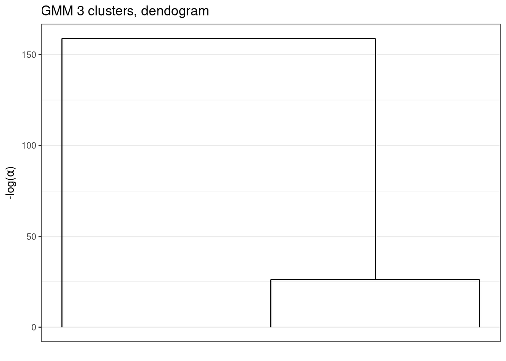

```r
plot(sol, type="tree")
```

Moreover, specific visualization functions are implemented for this model. For example, we may look at the *pairsplot* with associated cluster colors via the `gmmpairs()` function

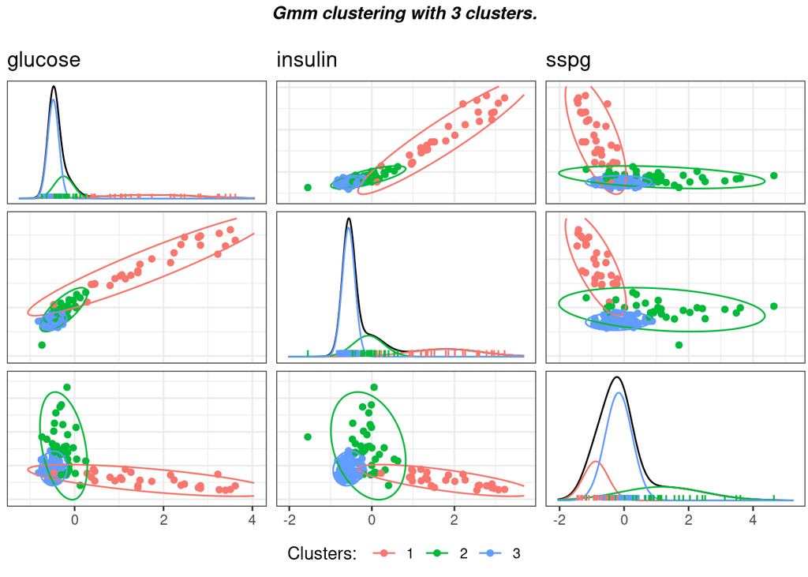

```r
gmmpairs(sol, X)
```

One can also investigate per-clusters marginal distributions with a *violin* plot via `plot()` and its `violins` type

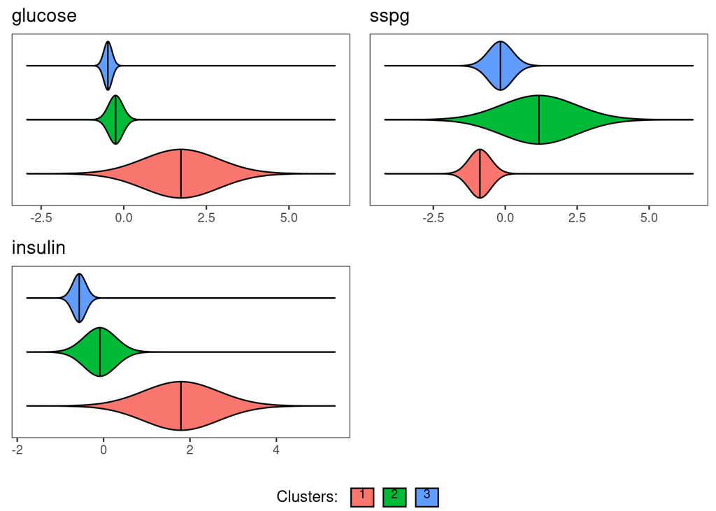

```r
plot(sol, type="violins")
```

#### Extract a conditional estimate of $\theta$

Furthermore, users may use the generic `coef()` function to get the mixture component parameters estimate. The result will be a simple list with fields for each parameters (means: `muk`, covariance matrices: `Sigmak`, proportions: `pi`).

```r
params = coef(sol)
names(params)
```

```
#> [1] "pi"     "muk"    "Sigmak"
```

```r
params$Sigmak[[2]]
```

```
#>             glucose     insulin       sspg
#> glucose  0.04732456  0.06098111 -0.1020909
#> insulin  0.06098111  0.13714310 -0.1359453
#> sspg    -0.10209092 -0.13594534  1.7013069
```

### Sensitivity analysis: impact of the hyper-parameters $\beta$

As explained above, the hyperparameters $\beta$ have no default “non-informative” values, and thus impact the clustering results. One may want to specify a priori belief that the Gaussian ellipse volume is small inside clusters, which amounts to diminish the $0.1$ coefficient in front of $\hat{\mathbf{\Sigma}}_{\mathbf{X}}$. In this case, it makes sense to decrease $\tau$ in the same proportions to keep a flat priors on the clusters means. For the diabetes data such a choice leads to an interesting solution, where the strong prior constraint leads to one cluster being created to fit one outlier in the “chemical” diabetes.

```r
sol_dense = greed(X,model=Gmm(epsilon=0.01*diag(diag(cov(X))), tau =0.001), alg=Hybrid(pop_size = 100))
```

```
#>
#> ── Fitting a GMM model ──
#>
#> ℹ Initializing a population of 100 solutions.
#> ℹ Generation 1 : best solution with an ICL of -361 and 10 clusters.
#> ℹ Generation 2 : best solution with an ICL of -316 and 6 clusters.
#> ℹ Generation 3 : best solution with an ICL of -293 and 4 clusters.
#> ℹ Generation 4 : best solution with an ICL of -290 and 4 clusters.
#> ℹ Generation 5 : best solution with an ICL of -290 and 4 clusters.
#> ℹ Generation 6 : best solution with an ICL of -290 and 4 clusters.
#> ── Final clustering ──
#>
#> ── Clustering with a GMM model 4 clusters and an ICL of -290
```

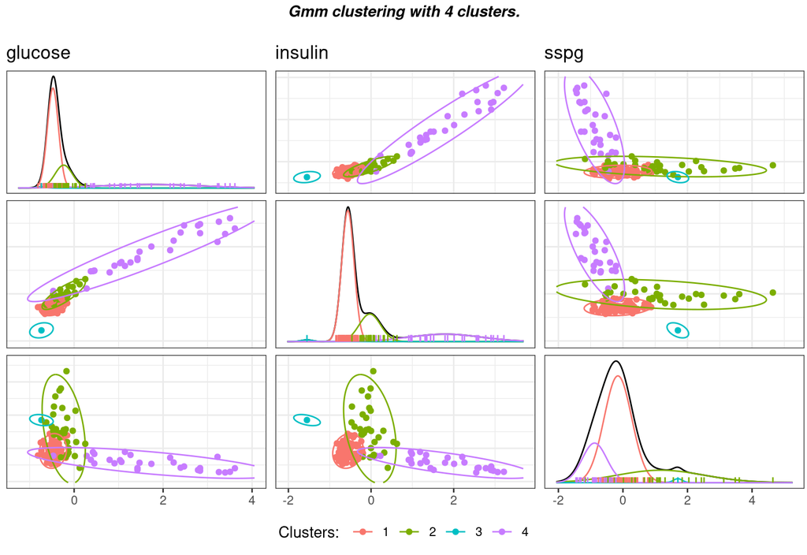

Matrix pairs plots of the clustering with user specified hyperparameters on the diabetes data.

```r
gmmpairs(sol_dense,X)
```

The first merge of the hierarchy recovers the previous partition with default parameters

```r
aricode::ARI(clustering(cut(sol_dense, 3)), clustering(sol))
```

```
#> [1] 0.9772411
```

# Categorical data clustering with the latent class analysis

Such datasets are typically represented using a [one-hot-encoding](https://en.wikipedia.org/wiki/One-hot#Machine_learning_and_statistics) of each factor in a design matrix $\mathbf{X} \in \{0,1\}^{n \times d}$ where $d = \sum_{j=1}^p d_j$. Latent class analysis (LCA) is a generative model for categorical data clustering which posits conditional independence of the factor variables conditionally on the (unknown) partition. Below is a description of its Bayesian formulation with the use of proper conjugate priors
$$\begin{equation}
\begin{aligned}
\pi&\sim \textrm{Dirichlet}(\alpha),\\
\forall k, \forall j, \quad \theta_{kj} &\sim
\textrm{Dirichlet}_{d_j}(\beta), \\
Z_i&\sim \mathcal{M}_K(1,\pi),\\
\forall j=1, \ldots, p, \quad X_{ij}|Z_{ik}=1 &\sim
\mathcal{M}_{d_j}(1, \theta_{kj}),\\
\end{aligned}
\end{equation}$$
For each cluster $k$ and variable $j$, the vector $\theta_{kj}$ represents the probability of each of the $d_j$ modalities. With the above choice of priors, the LCA model admits an exact ICL expression similar to the mixture of multinomials derived in [the supplementary materials](https://static-content.springer.com/esm/art%3A10.1007%2Fs11634-021-00440-z/MediaObjects/11634_2021_440_MOESM1_ESM.pdf) of Côme et. al. (2021, Section 3) .

The **greed** package implements this model via the `Lca` model-class and the default values for hyper-parameters are set as follows:

- $\alpha$ is set to 1
- $\beta$ is set to 1, defaulting to an uninformative uniform prior on $\theta_{kj}$

This default values may be changed and we refer to the `?Lca` documentation for further details.

### A real-data analysis: the mushroom dataset

**Mushroom** data from UCI Machine Learning Repository describing 8124 mushrooms with 22 phenotype variables. Each mushroom is classified as “edible” or “poisonous” and the goal is to recover the mushroom class from its phenotype. It comes attached with the **greed** package.

```r
data("mushroom")
```

#### Subsetting the data

We begin by forming the necessary vectors for analysis. The data has $n=8124$ rows and $p=23$ columns. The first column contains the poisonous status of each mushroom with two possible values, “p” for “poisonous” and “e” for edible, it will serve as the clustering we seek to recover.

```r
mushroom[,1:10] %>% head() %>% knitr::kable()
```

| edibility | V2 | V3 | V4 | V5 | V6 | V7 | V8 | V9 | V10 |
| --- | --- | --- | --- | --- | --- | --- | --- | --- | --- |
| p | x | s | n | t | p | f | c | n | k |
| e | x | s | y | t | a | f | c | b | k |
| e | b | s | w | t | l | f | c | b | n |
| p | x | y | w | t | p | f | c | n | n |
| e | x | s | g | f | n | f | w | b | k |
| e | x | y | y | t | a | f | c | b | n |

The remaining variables are used for clustering. Note that we only use a subset of the data for illustration purpose here.

```r
X = mushroom[,-1]
subset = sample(1:nrow(X), size = 1000)
label = mushroom$edibility[subset]
```

#### Clustering

The clustering is done via the main function `greed()` with argument `model` set to LCA and the genetic hybrid algorithm for ICL maximization.

> **Note:** The `Lca` model may only be used with datasets stored in a data.frame object containing factors only. When such data are provided to the `greed()` function, an `Lca` model is picked by default. To perform the clustering, it is therefore sufficient to call greed with the prepared data.frame.

```r
sol_mush<-greed(X[subset,], model=Lca())
```

```
#>
#> ── Fitting a LCA model ──
#>
#> ℹ Initializing a population of 20 solutions.
#> ℹ Generation 1 : best solution with an ICL of -13018 and 11 clusters.
#> ℹ Generation 2 : best solution with an ICL of -12817 and 16 clusters.
#> ℹ Generation 3 : best solution with an ICL of -12817 and 16 clusters.
#> ── Final clustering ──
#>
#> ── Clustering with a LCA model 15 clusters and an ICL of -12785
```

The hybrid genetic algorithm found a solution with $K=15$ clusters which is quite over-segmented. But, it display a good separation among edible and poisonous mushrooms:

```r
table(label, clustering(sol_mush)) %>% knitr::kable()
```

|  | 1 | 2 | 3 | 4 | 5 | 6 | 7 | 8 | 9 | 10 | 11 | 12 | 13 | 14 | 15 |
| --- | --- | --- | --- | --- | --- | --- | --- | --- | --- | --- | --- | --- | --- | --- | --- |
| e | 0 | 0 | 0 | 17 | 19 | 1 | 41 | 22 | 92 | 0 | 15 | 9 | 59 | 26 | 213 |
| p | 213 | 163 | 4 | 4 | 0 | 13 | 0 | 0 | 0 | 28 | 27 | 34 | 0 | 0 | 0 |

Partition’s NMI is 0.27 which is explained by the over-segmentation of the solution compared to the $2$-class problem.

#### Analysis of the hierarchy

Exploring the dendrogram provided by the hierarchical algorithm is quite useful in this case.

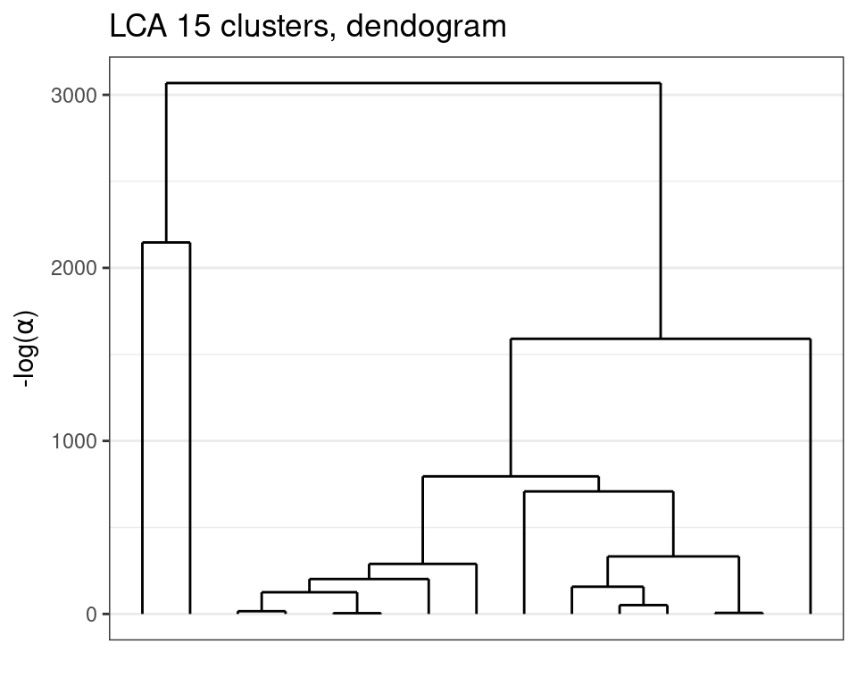

Dendogram obtained with greed with the Lca model on the Mushroom dataset.

```r
plot(sol_mush, type='tree')
```

We clearly see a hierarchical structure appearing with $K=2$ or $K=4$ main clusters. Thus, we can cut the tree at this height and look at the solution.

```r
sol2 = cut(sol_mush, 2)
table(label, clustering(sol2)) %>% knitr::kable(row.names = T) %>% kable_styling(full_width = F)
```

|  | 1 | 2 |
| --- | --- | --- |
| e | 0 | 514 |
| p | 376 | 110 |

#### Marginal plots

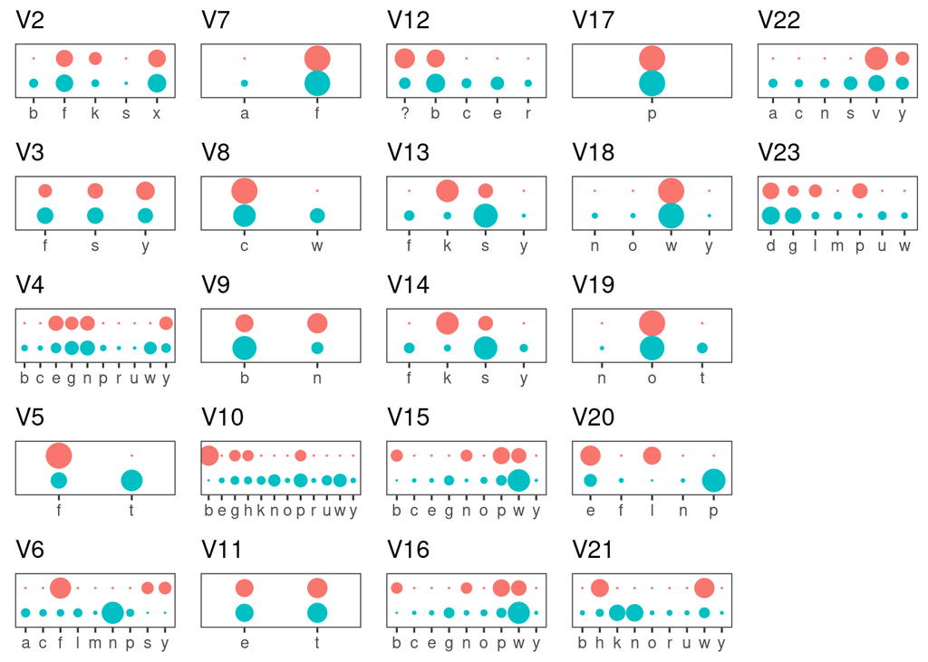

```r
plot(cut(sol_mush,2), type="marginals")
```

# Going further

You can go look at the vignettes for available models on the [package’s website](https://comeetie.github.io/greed/) !